# Exercise 5.3: Ancestral state reconstruction

## Exercise 5.3: Ancestral state reconstruction

### 1. Continuous characters

For better or for worse, the estimation of phenotypic trait values for ancestral nodes in the tree continues to be an important goal in phylogenetic comparative biology.

This tutorial focuses on the estimation of ancestral character states under Brownian motion & OU, including when some values for internal nodes are known.

Brownian evolution

To estimate the states for a continuously valued character at ancestral nodes, we need find the states that have the maximum probability of having arisen under our model. These will be our maximum likelihood estimates.

Since the nodes & tips in the tree have a multivariate normal distribution under Brownian motion, this is relatively simple in principle. We just find the set of parameters & states at internal nodes that maximize the logged, summed multivariate normal density.

```r
set.seed(10) ## for repeatability
## load phytools
library(phytools)
library(mnormt)
## simulate a tree & some data
tree<-pbtree(n=26,scale=1)
tree$tip.label<-LETTERS[26:1]
x<-fastBM(tree,internal=TRUE)
## let's try & write down the likelihood function we want
C<-vcvPhylo(tree)
pp<-rep(1,tree$Nnode+1)
lik<-function(pp,C,x) -sum(dmnorm(c(x,pp[3:length(pp)]),
    rep(pp[2],nrow(C)),pp[1]*C,log=TRUE))
tt<-setNames(c(1,rep(mean(x),tree$Nnode)),c("sig2",
    1:tree$Nnode+length(tree$tip)))
fit<-optim(tt,lik,C=C,x=x[1:26],method="L-BFGS-B",lower=
    c(1e-6,rep(-Inf,tree$Nnode)))
print(fit)
```

```
## $par
##     sig2       27       28       29       30       31       32       33
##  0.80637  0.04234  0.04131 -0.29093 -0.26592 -0.14393 -0.14126  0.09758
##       34       35       36       37       38       39       40       41
## -0.25697 -0.78612 -1.10074  0.41955  0.15515  0.27213 -1.07683  0.45436
##       42       43       44       45       46       47       48       49
##  1.25222  0.56337  0.04587  0.54224 -0.39063 -0.45769  1.18650 -0.10595
##       50       51
## -0.14957 -0.28287
##
## $value
## [1] 14.45
##
## $counts
## function gradient
##      111      111
##
## $convergence
## [1] 0
##
## $message
## [1] "CONVERGENCE: REL_REDUCTION_OF_F <= FACTR*EPSMCH"
```

(**Note that the fitted Brownian rate is not the same as the MLE of σ<sup>2</sup> conditioning only on the states for the tips of the tree. The rate estimated here will be too low because it treats the states at internal nodes as known, and then conditions on these states.)

We can easily check our estimates against the generating values:

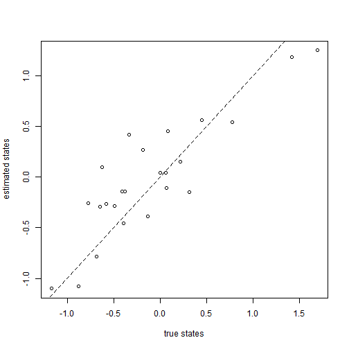

```r
plot(x[1:tree$Nnode+length(tree$tip.label)],fit$par[1:tree$Nnode+1],
    xlab="true states",ylab="estimated states")
lines(range(x),range(x),lty="dashed") ## 1:1 line
```

The problem with this method is that it will generally be inefficient at finding the ML solution as the number of nodes in our tree increases, and will even often fail to find the MLE. Luckily for the problem of ancestral state estimation under Brownian motion, relatively simple analytic solutions can be used. Let's take advantage of these to check our custom optimizer. If it worked, they should fall on the 1:1 line:

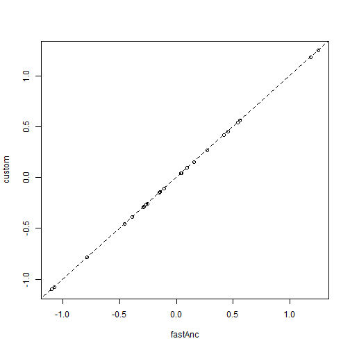

```r
aa<-fastAnc(tree,x[tree$tip.label])
plot(aa,fit$par[2:length(fit$par)],xlab="fastAnc",ylab="custom")
lines(range(x), range(x), lty = "dashed")  ## 1:1 line
```

One of the most common critiques of ancestral state estimation is that the uncertainty around ancestral states can be large; and, furthermore, that this uncertainty is often ignored. Let's address this by obtaining 95% CIs on ancestral values, and then let's show that the 95% CIs include the generating values around 95% of the time:

```r
## first, let's go back to our previous dataset
fit<-fastAnc(tree,x[tree$tip.label],CI=TRUE)
print(fit)
```

```
## $ace
##       27       28       29       30       31       32       33       34
##  0.04230  0.04127 -0.29096 -0.26592 -0.14394 -0.14128  0.09754 -0.25700
##       35       36       37       38       39       40       41       42
## -0.78615 -1.10076  0.41955  0.15516  0.27216 -1.07682  0.45441  1.25223
##       43       44       45       46       47       48       49       50
##  0.56345  0.04583  0.54225 -0.39067 -0.45769  1.18659 -0.10595 -0.14955
##       51
## -0.28285
##
## $CI95
##       [,1]    [,2]
## 27 -1.0725  1.1571
## 28 -1.0730  1.1556
## 29 -1.0396  0.4577
```

[output cut: 22 more lines]

```r
## this is the fraction of time that the true value is within our 95% CI
mean(((x[1:tree$Nnode+length(tree$tip.label)]>=fit$CI95[,1]) +
    (x[1:tree$Nnode+length(tree$tip.label)]<=fit$CI95[,2]))==2)
```

```
## [1] 1
```

One small tree doesn't tell us much, so let's repeat for a sample of trees & reconstructions:

```r
## custom function that conducts a simulation, estimates ancestral
## states, & returns the fraction on 95% CI
foo<-function(){
    tree<-pbtree(n=100)
    x<-fastBM(tree,internal=TRUE)
    fit<-fastAnc(tree,x[tree$tip.label],CI=TRUE)
    mean(((x[1:tree$Nnode+length(tree$tip.label)]>=fit$CI95[,1]) +
    (x[1:tree$Nnode+length(tree$tip.label)]<=fit$CI95[,2]))==2)
}
## conduct 100 simulations
pp<-replicate(100,foo())
mean(pp)
```

```
## [1] 0.953
```

Cool. Well, this shows us that although CIs can be large, when the model is correct they will include the generating value (1-α)% of the time.

Ornstein-Uhlenbeck model

It is also possible to estimate ancestral states using other models of character evolution other than Brownian motion. It is possible to, for instance, estimate ancestral states under the OU model that we have already learned. One note of caution: when the selection parameter (α) is very large, then the ancestral states will all tend towards the same value (the fitted optimum, θ).

For this example, we will use the function `anc.ML` which permits us to specify an OU model:

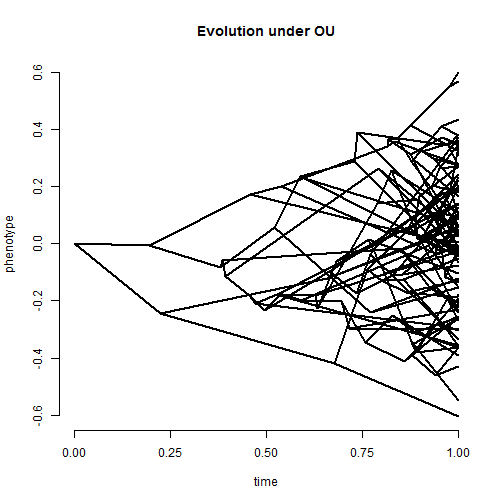

```r
## simulate tree & data under the OU model
alpha<-2
tree<-pbtree(n=100,scale=1)
x<-fastBM(tree,internal=TRUE,model="OU",alpha=alpha,sig2=0.2)
phenogram(tree,x,ftype="off")
title("Evolution under OU")
```

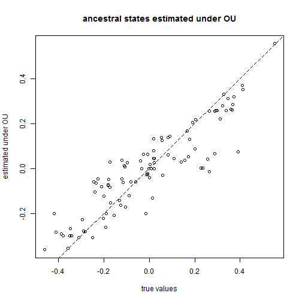

```r
## fit the model (this may be slow)
aa<-anc.ML(tree,x[tree$tip.label],model="OU")
plot(x[1:tree$Nnode+length(tree$tip.label)],aa$ace,
xlab="true values",ylab="estimated under OU")
lines(range(x),range(x),lty="dashed")
title("ancestral states estimated under OU")
```

Ancestral state estimates when some nodes are known

We can theoretically fix the state for any internal node during MLE of ancestral states. In practice, we would do this by attaching a terminal edge of zero length to the internal node we wanted to fix, and then treat it like another tip value in our analyses.

Another possibility, which also allows for the possibility that ancestral states are uncertain, is to use an informative *prior probability density* on one or multiple states at internal nodes, and then estimate ancestral states using Bayesian MCMC.

Let's try this using a really bad case for ancestral character estimation from contemporaneous tip data: Brownian evolution with a trend. Note that although we theoretically could do so - we are not fitting a trended model here.

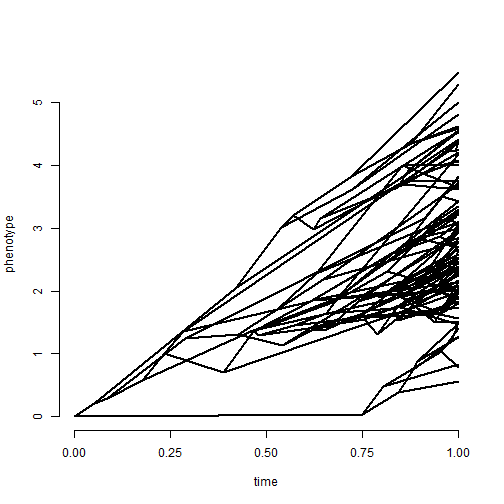

```r
tree<-pbtree(n=100,scale=1)
## simulate data with a trend
x<-fastBM(tree,internal=TRUE,mu=3)
phenogram(tree,x,ftype="off")
```

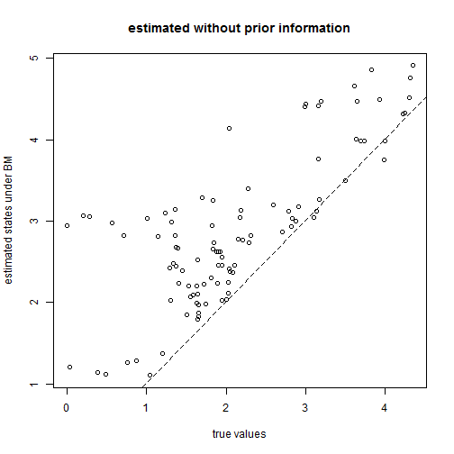

```r
## let's see how bad we do if we ignore the trend
plot(x[1:tree$Nnode+length(tree$tip.label)],
fastAnc(tree,x[tree$tip.label]),
xlab="true values",ylab="estimated states under BM")
lines(range(x),range(x),lty="dashed")
title("estimated without prior information")
```

```r
## incorporate prior knowledge
pm<-setNames(c(1000,rep(0,tree$Nnode)),
    c("sig2",1:tree$Nnode+length(tree$tip.label)))
## the root & two randomly chosen nodes
nn<-as.character(c(length(tree$tip.label)+1,
    sample(2:tree$Nnode+length(tree$tip.label),2)))
pm[nn]<-x[nn]
## prior variance
pv<-setNames(c(1000^2,rep(1000,length(pm)-1)),names(pm))
pv[as.character(nn)]<-1e-100
## run MCMC
mcmc<-anc.Bayes(tree,x[tree$tip.label],ngen=100000,
    control=list(pr.mean=pm,pr.var=pv,
    a=pm[as.character(length(tree$tip.label)+1)],
    y=pm[as.character(2:tree$Nnode+length(tree$tip.label))]))
```

```
## Control parameters (set by user or default):
```

```
## List of 7
##  $ sig2   : num 0.87
##  $ a      : Named num 0
##   ..- attr(*, "names")= chr "101"
##  $ y      : Named num [1:98] 0 0 0 0 0 0 0 0 0 0 ...
##   ..- attr(*, "names")= chr [1:98] "102" "103" "104" "105" ...
##  $ pr.mean: Named num [1:100] 1000 0 0 0 0 0 0 0 0 0 ...
##   ..- attr(*, "names")= chr [1:100] "sig2" "101" "102" "103" ...
##  $ pr.var : Named num [1:100] 1e+06 1e-100 1e+03 1e+03 1e+03 ...
##   ..- attr(*, "names")= chr [1:100] "sig2" "101" "102" "103" ...
##  $ prop   : num [1:100] 0.0087 0.0087 0.0087 0.0087 0.0087 ...
##  $ sample : num 100
```

```
## Starting MCMC...
## Done MCMC.
```

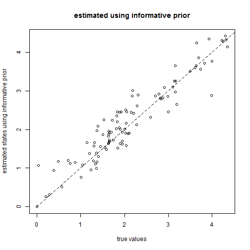

```r
aa<-colMeans(mcmc[201:1001,as.character(1:tree$Nnode+length(tree$tip.label))])
plot(x[names(aa)],aa,xlab="true values",
ylab="estimated states using informative prior")
lines(range(x),range(x),lty="dashed")
title("estimated using informative prior")
```

### 2. Discrete characters

This tutorial focuses on the estimation of ancestral character states for discretely valued traits using a continuous-time Markov chain model commonly known as the Mk model.

`"phytools"` has a function for ancestral character estimation under a couple of different models that uses the re-rooting method of Yang (1995). For other models of evolutionary change not covered by this function, users should try Rich Fitzjohn's [diversitree](http://www.zoology.ubc.ca/prog/diversitree/) package.

OK - let's pull our data from the *Anolis* ecomorph tree to use in these analyses:

```r
data(anoletree)
x<-getStates(anoletree,"tips")
tree<-anoletree
rm(anoletree)
tree
```

```
##
## Phylogenetic tree with 82 tips and 81 internal nodes.
##
## Tip labels:
##  Anolis_ahli, Anolis_allogus, Anolis_rubribarbus, Anolis_imias, Anolis_sagrei, Anolis_bremeri, ...
##
## Rooted; includes branch lengths.
```

```r
x
```

```
##            Anolis_ahli         Anolis_allogus     Anolis_rubribarbus
##                   "TG"                   "TG"                   "TG"
##           Anolis_imias          Anolis_sagrei         Anolis_bremeri
##                   "TG"                   "TG"                   "TG"
## Anolis_quadriocellifer      Anolis_ophiolepis         Anolis_mestrei
##                   "TG"                   "GB"                   "TG"
##           Anolis_jubar      Anolis_homolechis        Anolis_confusus
##                   "TG"                   "TG"                   "TG"
##           Anolis_guafe         Anolis_garmani        Anolis_opalinus
##                   "TG"                   "CG"                   "TC"
##         Anolis_grahami     Anolis_valencienni      Anolis_lineatopus
##                   "TC"                   "Tw"                   "TG"
##       Anolis_evermanni       Anolis_stratulus           Anolis_krugi
##                   "TC"                   "TC"                   "GB"
##      Anolis_pulchellus       Anolis_gundlachi       Anolis_poncensis
##                   "GB"                   "TG"                   "GB"
##           Anolis_cooki    Anolis_cristatellus    Anolis_brevirostris
##                   "TG"                   "TG"                   "Tr"
##        Anolis_caudalis          Anolis_marron        Anolis_websteri
##                   "Tr"                   "Tr"                   "Tr"
##       Anolis_distichus         Anolis_alumina    Anolis_semilineatus
##                   "Tr"                   "GB"                   "GB"
##         Anolis_olssoni       Anolis_insolitus       Anolis_whitemani
##                   "GB"                   "Tw"                   "TG"
##       Anolis_haetianus        Anolis_breslini         Anolis_armouri
##                   "TG"                   "TG"                   "TG"
##         Anolis_cybotes         Anolis_shrevei   Anolis_longitibialis
##                   "TG"                   "TG"                   "TG"
##         Anolis_strahmi        Anolis_marcanoi        Anolis_baleatus
##                   "TG"                   "TG"                   "CG"
##       Anolis_barahonae        Anolis_ricordii         Anolis_cuvieri
##                   "CG"                   "CG"                   "CG"
##   Anolis_altitudinalis        Anolis_oporinus        Anolis_isolepis
##                   "TC"                   "TC"                   "TC"
##        Anolis_allisoni        Anolis_porcatus        Anolis_loysiana
##                   "TC"                   "TC"                   "Tr"
##         Anolis_guazuma        Anolis_placidus        Anolis_sheplani
##                   "Tw"                   "Tw"                   "Tw"
##         Anolis_alayoni     Anolis_angusticeps        Anolis_paternus
##                   "Tw"                   "Tw"                   "Tw"
##       Anolis_alutaceus    Anolis_inexpectatus       Anolis_clivicola
##                   "GB"                   "GB"                   "GB"
##    Anolis_cupeyalensis    Anolis_cyanopleurus         Anolis_alfaroi
##                   "GB"                   "GB"                   "GB"
##      Anolis_macilentus       Anolis_vanidicus        Anolis_baracoae
##                   "GB"                   "GB"                   "CG"
##          Anolis_noblei      Anolis_smallwoodi    Anolis_luteogularis
##                   "CG"                   "CG"                   "CG"
##       Anolis_equestris   Anolis_bahorucoensis Anolis_dolichocephalus
##                   "CG"                   "GB"                   "GB"
##      Anolis_hendersoni     Anolis_darlingtoni        Anolis_aliniger
##                   "GB"                   "Tw"                   "TC"
##      Anolis_singularis    Anolis_chlorocyanus     Anolis_coelestinus
##                   "TC"                   "TC"                   "TC"
##        Anolis_occultus
##                   "Tw"
```

In visual format, these are the data that we have:

```r
plotTree(tree,type="fan",fsize=0.9,ftype="i")
```

```
## setEnv=TRUE for this type is experimental. please be patient with bugs
```

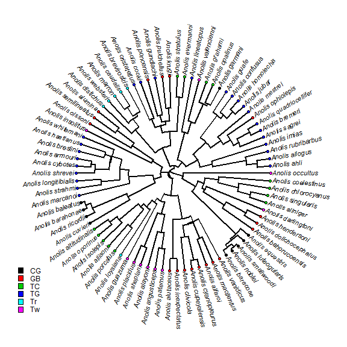

```r
cols<-setNames(palette()[1:length(unique(x))],sort(unique(x)))
tiplabels(pie=to.matrix(x,sort(unique(x))),piecol=cols,cex=0.2)
add.simmap.legend(colors=cols,prompt=FALSE,x=0.9*par()$usr[1],
    y=-max(nodeHeights(tree)))
```

Next, let's fit a single-rate model & reconstruct ancestral states at internal nodes in the tree.

```r
## estimate ancestral states under a ER model
fitER<-rerootingMethod(tree,x,model="ER")
print(lapply(fitER,round,digits=3))
```

```
## $loglik
## [1] -78.05
##
## $Q
##        CG     GB     TC     TG     Tr     Tw
## CG -0.116  0.023  0.023  0.023  0.023  0.023
## GB  0.023 -0.116  0.023  0.023  0.023  0.023
## TC  0.023  0.023 -0.116  0.023  0.023  0.023
## TG  0.023  0.023  0.023 -0.116  0.023  0.023
## Tr  0.023  0.023  0.023  0.023 -0.116  0.023
## Tw  0.023  0.023  0.023  0.023  0.023 -0.116
##
## $marginal.anc
##        CG    GB    TC    TG    Tr    Tw
## 83  0.018 0.202 0.043 0.429 0.004 0.304
```

[output cut: 80 more lines]

The element `marginal.anc` gives us the marginal ancestral states, also known as the 'empirical Bayesian posterior probabilities.'

It is fairly straightforward to overlay these posterior probabilities on the tree:

```r
plotTree(tree,type="fan",fsize=0.9,ftype="i")
```

```
## setEnv=TRUE for this type is experimental. please be patient with bugs
```

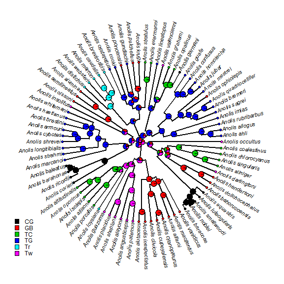

```r
nodelabels(node=as.numeric(rownames(fitER$marginal.anc)),
    pie=fitER$marginal.anc,piecol=cols,cex=0.5)
tiplabels(pie=to.matrix(x,sort(unique(x))),piecol=cols,cex=0.2)
add.simmap.legend(colors=cols,prompt=FALSE,x=0.9*par()$usr[1],
    y=-max(nodeHeights(tree)))
```

An alternative approach to the one outline above is to use an MCMC approach to sample character histories from their posterior probability distribution. This is called stochastic character mapping (Huelsenbeck et al. 2003). The model is the same but in this case we get a sample of unambiguous histories for our discrete character's evolution on the tree - rather than a probability distribution for the character at nodes.

For instance, given the data simulated above - we can generate the stochastic character map as follows:

```r
## simulate single stochastic character map using empirical Bayes method
mtree<-make.simmap(tree,x,model="ER")
```

```
## make.simmap is sampling character histories conditioned on the transition matrix
## Q =
```

```
##          CG       GB       TC       TG       Tr       Tw
## CG -0.11571  0.02314  0.02314  0.02314  0.02314  0.02314
## GB  0.02314 -0.11571  0.02314  0.02314  0.02314  0.02314
## TC  0.02314  0.02314 -0.11571  0.02314  0.02314  0.02314
## TG  0.02314  0.02314  0.02314 -0.11571  0.02314  0.02314
## Tr  0.02314  0.02314  0.02314  0.02314 -0.11571  0.02314
## Tw  0.02314  0.02314  0.02314  0.02314  0.02314 -0.11571
```

```
## (estimated using likelihood);
## and (mean) root node prior probabilities
## pi =
```

```
##     CG     GB     TC     TG     Tr     Tw
## 0.1667 0.1667 0.1667 0.1667 0.1667 0.1667
```

```
## Done.
```

```r
plotSimmap(mtree,cols,type="fan",fsize=0.9,ftype="i")
```

```
## setEnv=TRUE for this type is experimental. please be patient with bugs
```

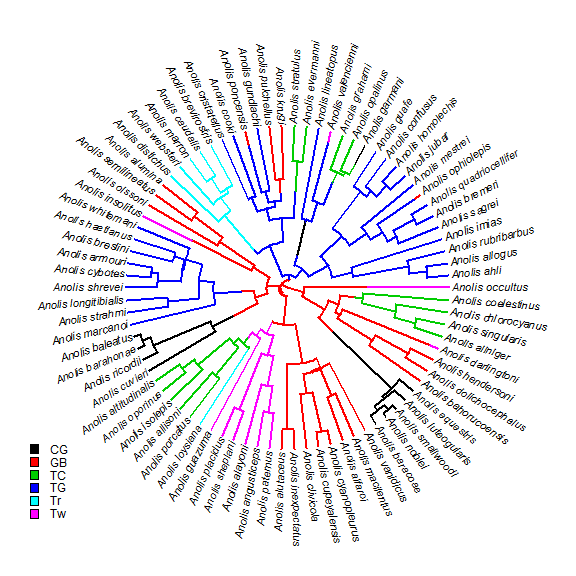

```r
add.simmap.legend(colors=cols,prompt=FALSE,x=0.9*par()$usr[1],
    y=-max(nodeHeights(tree)))
```

A single stochastic character map does not mean a whole lot in isolation - we need to look at the whole distribution from a sample of stochastic maps. This can be a bit overwhelming. For instance, the following code generates 100 stochastic character maps from our dataset and plots them in a grid:

```r
mtrees<-make.simmap(tree,x,model="ER",nsim=100)
```

```
## make.simmap is sampling character histories conditioned on the transition matrix
## Q =
```

```
##          CG       GB       TC       TG       Tr       Tw
## CG -0.11571  0.02314  0.02314  0.02314  0.02314  0.02314
## GB  0.02314 -0.11571  0.02314  0.02314  0.02314  0.02314
## TC  0.02314  0.02314 -0.11571  0.02314  0.02314  0.02314
## TG  0.02314  0.02314  0.02314 -0.11571  0.02314  0.02314
## Tr  0.02314  0.02314  0.02314  0.02314 -0.11571  0.02314
## Tw  0.02314  0.02314  0.02314  0.02314  0.02314 -0.11571
```

```
## (estimated using likelihood);
## and (mean) root node prior probabilities
## pi =
```

```
##     CG     GB     TC     TG     Tr     Tw
## 0.1667 0.1667 0.1667 0.1667 0.1667 0.1667
```

```
## Done.
```

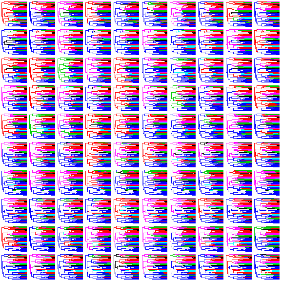

```r
par(mfrow=c(10,10))
plotSimmap(mtrees,cols,lwd=1,ftype="off")
```

It's possible to summarize a set of stochastic maps in a much more meaningful way. For instance, we can estimate the number of changes of each type, the proportion of time spent in each state, and the posterior probabilities that each internal node is in each state, under our model. For example:

```r
pd<-describe.simmap(mtrees,plot=FALSE)
pd
```

```
## 100 trees with a mapped discrete character with states:
##  CG, GB, TC, TG, Tr, Tw
##
## trees have 23.83 changes between states on average
##
## changes are of the following types:
##      CG,GB CG,TC CG,TG CG,Tr CG,Tw GB,CG GB,TC GB,TG GB,Tr GB,Tw TC,CG
## x->y  0.22  0.23  0.15  0.13  0.17   0.7  0.97  1.27  0.42  1.32  1.18
##      TC,GB TC,TG TC,Tr TC,Tw TG,CG TG,GB TG,TC TG,Tr TG,Tw Tr,CG Tr,GB
## x->y  0.55  0.47  0.69  0.92  0.84  3.16  1.58  1.04  1.74  0.17  0.22
##      Tr,TC Tr,TG Tr,Tw Tw,CG Tw,GB Tw,TC Tw,TG Tw,Tr
## x->y  0.28  0.14  0.28  0.68  1.33  1.67  0.76  0.55
##
## mean total time spent in each state is:
##            CG      GB      TC      TG       Tr      Tw total
## raw  12.61111 47.2703 32.2042 68.3021 13.11033 32.1689 205.7
## prop  0.06132  0.2298  0.1566  0.3321  0.06375  0.1564   1.0
```

```r
## now let's plot a random map, and overlay the posterior probabilities
plotSimmap(mtree,cols,type="fan",fsize=0.9,ftype="i")
```

```
## setEnv=TRUE for this type is experimental. please be patient with bugs
```

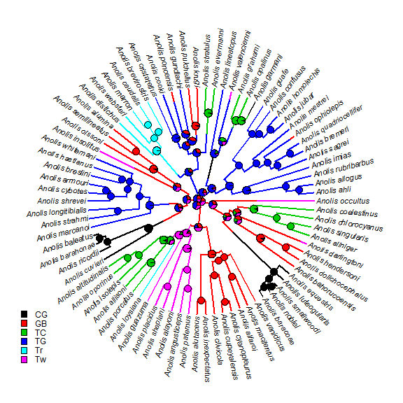

```r
nodelabels(pie=pd$ace,piecol=cols,cex=0.5)
add.simmap.legend(colors=cols,prompt=FALSE,x=0.9*par()$usr[1],
    y=-max(nodeHeights(tree)))
```

Finally, since we obtained these inferences under exactly the same model, let's compare the posterior probabilities from stochastic mapping with our marginal ancestral states. In the former case, our probabilities were obtained by sampling from the joint (rather than marginal) probability distribution for the ancestral states.

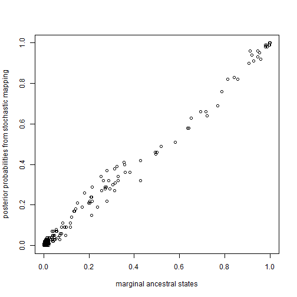

```r
plot(fitER$marginal.anc,pd$ace,xlab="marginal ancestral states",
    ylab="posterior probabilities from stochastic mapping")
```

This tells us that although joint & marginal reconstruction are not the same, the marginal probabilities from joint stochastic sampling and the marginal ancestral states are quite highly correlated - at least in this case study.

*Written by Liam J. Revell. Last updated August 7, 2014*